# Project 2: Data Mining, Classification, Prediction

### Dimensionality Reduction with PCA

```r
# PCA code here
nbaclusterdata[c("Points", "Rebounds", "Assists")]
```

```
## # A tibble: 48 x 3
##    Points Rebounds Assists
##     <dbl>    <dbl>   <dbl>
##  1   13.9      9.5     1.6
##  2   21.3      9.2     2.4
##  3   27.7     12.5     5.9
##  4   25.6      5       5.5
##  5   15.9      4.6     5.5
##  6   26.6      4.1     6.8
##  7   18.7      5.3     4
##  8   19.5      9.8     2
##  9   21.1      3.4     6.4
## 10   27.3      5.3     5.2
## # … with 38 more rows
```

```r
nbapca <- nbaclusterdata[c("Points", "Rebounds", "Assists")]
pca1 <- princomp(nbapca, cor = T)
summary(pca1, loadings = T)
```

```
## Importance of components:
##                           Comp.1    Comp.2    Comp.3
## Standard deviation     1.1141882 1.0629547 0.7929135
## Proportion of Variance 0.4138051 0.3766243 0.2095706
## Cumulative Proportion  0.4138051 0.7904294 1.0000000
##
## Loadings:
##          Comp.1 Comp.2 Comp.3
## Points    0.655  0.464  0.596
## Rebounds -0.134  0.848 -0.513
## Assists   0.743 -0.256 -0.618
```

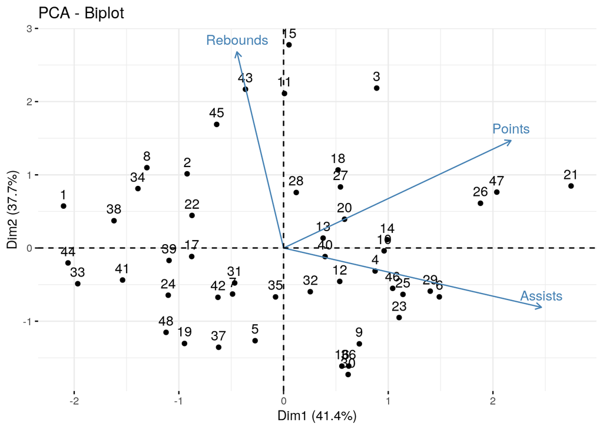

```r
library(factoextra)
fviz_pca_biplot(pca1)
```

### Linear Classifier

```r
# linear classifier code here
logistic_fit <- glm(Citzenship == "USA" ~ Salary + Weight + Points +
    Blocks + Steals + Assists + Rebounds + Age + MP + G, data = nbastats,
    family = "binomial")
prob_reg <- predict(logistic_fit, type = "response")
class_diag(prob_reg, nbastats$Citzenship, positive = "USA")
```

```
##            acc sens   spec    ppv     f1     ba    auc
## Metrics 0.9375    1 0.7692 0.9211 0.9589 0.8846 0.9429
```

```r
y <- nbastats$Citzenship
y <- factor(y, levels = c("International", "USA"))
y_hat <- sample(c("International", "USA"), size = length(y),
    replace = T)
y_hat <- factor(y_hat, levels = c("International", "USA"))
table(actual = y, predicted = y_hat)
```

```
##                predicted
## actual          International USA
##   International             5   8
##   USA                      15  20
```

```r
# cross-validation of linear classifier here
set.seed(322)

k = 10

data <- sample_frac(nbastats)
folds <- rep(1:k, length.out = nrow(data))

diags <- NULL

i = 1
for (i in 1:k) {
    train <- data[folds != i, ]
    test <- data[folds == i, ]
    truth <- test$Citzenship


    fit <- glm(Citzenship == "USA" ~ Salary + Weight + Points +
        Blocks + Steals + Assists + Rebounds + Age + MP + G,
        data = test, family = "binomial")


    probs <- predict(fit, type = "response")


    diags <- rbind(diags, class_diag(probs, truth, positive = "USA"))
}


summarize_all(diags, mean)
```

```
##   acc sens spec ppv f1  ba auc
## 1   1    1  NaN   1  1 NaN   1
```

### Non-Parametric Classifier

```r
library(caret)
# non-parametric classifier code here
knn_fit <- knn3(Citzenship == "USA" ~ Salary + Weight + Points +
    Blocks + Steals + Assists + Rebounds + Age + MP + G, data = nbastats)
probs_knn <- predict(knn_fit, nbastats)[, 2]
class_diag(probs_knn, nbastats$Citzenship, positive = "USA")
```

```
##          acc   sens   spec    ppv     f1    ba   auc
## Metrics 0.75 0.9143 0.3077 0.7805 0.8421 0.611 0.767
```

```r
y <- nbastats$Citzenship
y <- factor(y, levels = c("International", "USA"))
y_hat <- sample(c("International", "USA"), size = length(y),
    replace = T)
y_hat <- factor(y_hat, levels = c("International", "USA"))
table(actual = y, predicted = y_hat)
```

```
##                predicted
## actual          International USA
##   International             4   9
##   USA                      18  17
```

```r
# cross-validation of np classifier here
set.seed(322)
k = 10

data <- sample_frac(nbastats)
folds <- rep(1:k, length.out = nrow(data))

diags <- NULL

i = 1
for (i in 1:k) {
    train <- data[folds != i, ]
    test <- data[folds == i, ]
    truth <- test$Citzenship


    fit <- knn3(Citzenship == "True" ~ Salary + Weight + Points +
        Blocks + Steals + Assists + Rebounds + Age + MP + G,
        data = test)


    probs <- predict(fit, newdata = test)[, 1]


    diags <- rbind(diags, class_diag(probs, truth, positive = "USA"))
}

summarize_all(diags, mean)
```

```
##    acc sens spec  ppv      f1  ba  auc
## 1 0.73    1  NaN 0.73 0.83412 NaN 0.55
```

Discussion

*This time, a non-parametric classifier was used (k-nearest-neighbors) to the exact same dataset/variables that I used with the linear classifier above. The AUC values have decreased significantly when utilizing kNN. The AUC values were 0.77 prior to the k-fold and 0.55 after doing a k-fold to the same model. The decrease in AUC values indicates that there was overfitting. Overall,the logistic regression model performed the best per AUC.*

### Regression/Numeric Prediction

```r
# regression model code here
linearfit <- lm(Points ~ ., data = nbaclusterdata)
linearyhat <- predict(linearfit)
mean((nbaclusterdata$Points - linearyhat)^2)
```

```
## [1] 8.50655
```

```r
# cross-validation of regression model here
set.seed(1234)
k = 5
data <- nbaclusterdata[sample(nrow(nbaclusterdata)), ]
folds <- cut(seq(1:nrow(nbaclusterdata)), breaks = k, labels = F)
diags <- NULL
set.seed(1234)
k = 5
data <- nbaclusterdata[sample(nrow(nbaclusterdata)), ]
folds <- cut(seq(1:nrow(nbaclusterdata)), breaks = k, labels = F)
diags <- NULL
for (i in 1:k) {
    train <- data[folds != i, ]
    test <- data[folds == i, ]

    linearfit <- lm(Points ~ ., data = train)

    linearyhat <- predict(linearfit, newdata = test)

    diags <- mean((test$Points - linearyhat)^2)
}
mean(diags)
```

```
## [1] 5.050184
```

Discussion

*In this section, a linear regression model was performed for the nbaclusterdata dataset because the original nbastats dataset was running into errors. I believe it was due to the fact that the original the nbastats data involved character variables such as the names of the NBA players. The points variable was being predicted from all other variables. The MSE value came out to be 8.50655 which is fairly a low measure of prediction error. Next, the average MSE across the k testing folds came out to be 5.050184. It can be concluded that the MSE was lower in CV, which is a good sign (means no overfitting).*

### Python

```r
library(reticulate)
use_python("/usr/bin/python3", required = F)
testing <- "Basketball is"
```

```python
# python code here
testing="my favorite sport."
print(r.testing,testing)
```

```
## Basketball is my favorite sport.
```

```r
testing <- "Basketball is"
cat(c(testing, py$testing))
```

```
## Basketball is my favorite sport.
```

Discussion

*Utilizing the reticualte package, I was able to utilize python codes and r codes all on this R Markdown. Just as we have been doing all semester, I have created a character vector under the {R} code section called “testing” which contains the text “Basketball is”. Additionally, I did the same thing under the {python} code section except the code “testing” contained the text “my favorite sport”. Despite having the same code name “testing”, utilizing the r. code under {python} section and py$ code under the {R} section allowed me to print out the phrase “Basketball is my favorite sport”. This method allowed me to have objects be named the same thing without having any conflicts. The code r. allowed me to access R-Defined objects under the python code chunk area and the code py$ allowed me to access python-defined objects under the r code chunk area.*